# Analyses of GSE188397

## Volcano Plot with Gene Length

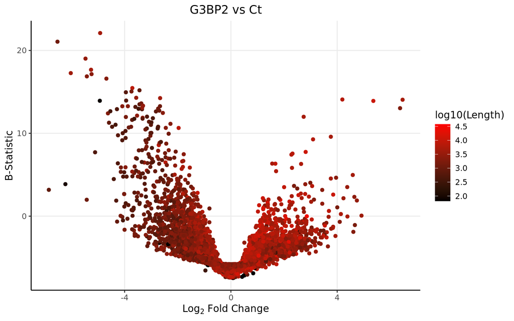

```r
DEGenes_BP2.vs.CT$Gene <- row.names(DEGenes_BP2.vs.CT)
colnames(genelength) <- c("Length","Gene")
DEGenes_BP2.vs.CT <- merge(DEGenes_BP2.vs.CT, genelength, by="Gene")

ggplot(data=DEGenes_BP2.vs.CT,
                 aes(x=logFC,
                     y=  B)) +
  geom_point(aes(color=log10(Length)))+
  theme_bw() +
  theme(axis.line = element_line(colour = "black"),
        panel.grid.minor = element_blank(),
        panel.border = element_blank(),
        panel.background = element_blank()) +
  ggtitle("G3BP2 vs Ct")+ xlab(expression(Log[2] ~ Fold ~ Change)) + ylab("B-Statistic") +
  theme(plot.title = element_text(hjust = 0.5))  +
  scale_colour_gradient(low = "black", high = "red")+ theme(text=element_text(family = "Quicksand"))
```

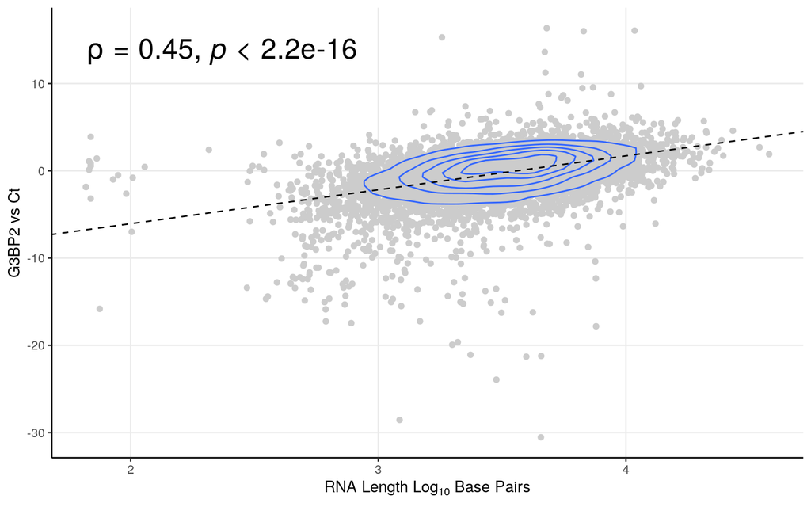

```r
smooth.SG <- lm(t~log10(Length), DEGenes_BP2.vs.CT)
liner.SG <- rstandard(smooth.SG)
DEGenes_BP2.vs.CT <-cbind(DEGenes_BP2.vs.CT, liner.SG)
colnames(DEGenes_BP2.vs.CT)[9] <- "Residuals"
row.names(DEGenes_BP2.vs.CT) <- DEGenes_BP2.vs.CT$Gene
linemarkers <- as.data.frame(DEGenes_BP2.vs.CT[abs(DEGenes_BP2.vs.CT$Residuals)>4,])

# Calculate the Spearman correlation coefficient
spearman_corr <- cor(DEGenes_BP2.vs.CT$t, log10(DEGenes_BP2.vs.CT$Length), method = "spearman")



ggplot(DEGenes_BP2.vs.CT, aes(y=t, x=log10(Length))) + geom_point(color="#CCCCCC", alpha=1) +   theme_bw()+ geom_density_2d()+
 ylab("G3BP2 vs Ct") + xlab(expression(RNA ~ Length ~ Log[10] ~ Base ~ Pairs)) +
  theme(axis.line = element_line(colour = "black"),
        panel.grid.minor = element_blank(),
        panel.border = element_blank(),
        panel.background = element_blank()) +
  theme(plot.title = element_text(hjust = 0.5))  +
  geom_abline(slope=smooth.SG$coefficients[2], intercept = smooth.SG$coefficients[1], linetype = "dashed")+ stat_cor(method = "spearman", cor.coef.name = "rho",size=7)
```

We see a bias towards longer transcripts.

## Expression Graphs (Extra QC)

As an added control, lets plot these genes in regard to their expression, and contamination.

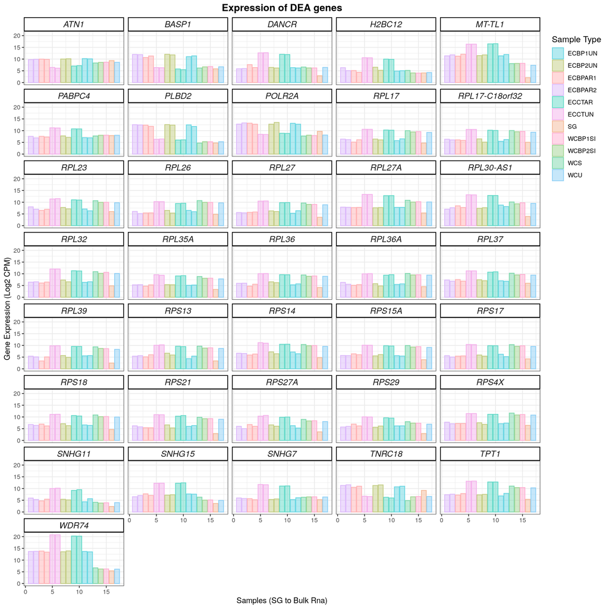

```r
upmarkers <- as.data.frame(DEGenes_BP2.vs.CT[DEGenes_BP2.vs.CT$logFC>2 & DEGenes_BP2.vs.CT$B>10,] )
downmarkers <- as.data.frame(DEGenes_BP2.vs.CT[DEGenes_BP2.vs.CT$logFC< -3.5 & DEGenes_BP2.vs.CT$B>10,] )

finagenes <- rbind(upmarkers, downmarkers)

dfforexpression <- dfforpca[-c(1:2),]
samplecodes <- data.frame(samples=row.names(dfforexpression), purity=c(1:17))
sampletype <- data.frame(samples=row.names(dfforexpression), sampletype=fordescriptive)
dfforexpression <- t(dfforexpression)
genesforexp <- dfforexpression[row.names(dfforexpression)%in%row.names(finagenes),]
genesforexp <- reshape2::melt(genesforexp)
colnames(genesforexp) <- c("Gene", "samples", "expression")
genesforexp <- merge(genesforexp, samplecodes, by="samples")
genesforexp <- merge(genesforexp, sampletype, by="samples")
genesforexp <- genesforexp[,-1]
genesforexp[,2] <- as.numeric(genesforexp[,2])
genesforexp[,1] <- as.character(genesforexp[,1])
genesforexp <- genesforexp[order(genesforexp$Gene),]


winnyplot <- ggplot(genesforexp, aes(x=purity, y=expression, fill=sampletype, colour=sampletype)) + geom_bar(position="dodge", stat="identity", alpha=0.5) + facet_wrap(.~ Gene, ncol=5)
winnyplot <- winnyplot + scale_fill_manual(name = "Sample Type", values = custom_palette) + scale_colour_manual(name = "Sample Type", values = custom_palette)
winnyplot <- winnyplot + theme_bw() + xlab("Samples (SG to Bulk Rna)") + ylab("Gene Expression (Log2 CPM)") + theme(
      strip.text.x = element_text(
        size = 12, face="italic"
        )) +
 theme(
   strip.background = element_rect(
     color="black", fill="#FFFFFF", size=1, linetype="solid"
     )
   ) + theme(
    #legend.position = c(.95, .40),
    legend.justification = c("right", "top"),
    legend.box.just = "right",
    ) + theme(legend.title = element_text(size = 12)) + ggtitle("Expression of DEA genes") + theme(plot.title = element_text(hjust = 0.5, size=14, face="bold"))
winnyplot
```

## GSEA

Now that we have our genes of interest, it would also be interesting to see what are the **altered gene sets** between upregulated and downregulated transcripts from the above comparison. Therefore, lets perform a *Gene Set Enrichment Analysis*

```r
#for all genes
DEGenes_BP2.vs.CT <- DEGenes_BP2.vs.CT[order(DEGenes_BP2.vs.CT[,4]),]
gseatool <- DEGenes_BP2.vs.CT[,4]
gseatool <- as.data.frame(gseatool)
colnames(gseatool)[1] <- "t"
gseatool[,2] <- DEGenes_BP2.vs.CT$Gene
colnames(gseatool)[2] <- "Symbol"
gseatool <- gseatool[,c(2,1)]

vectorranks <- gseatool$t
names(vectorranks) <- gseatool$Symbol


#to load our pathways
hallmarks.gs <- msigdbr(species = "Homo sapiens", collection =  "H")

hallmarks.gsets <- hallmarks.gs %>% split(x = .$gene_symbol, f = .$gs_name)

for (set in names(hallmarks.gsets)){
  hallmarks.gsets[[set]] <- toupper(hallmarks.gsets[[set]])
}

hallmarks.res <- fgsea(pathways = hallmarks.gsets,
                       stats = vectorranks)
hallmarks.res.tidy <- hallmarks.res %>%
  as_tibble() %>%
  arrange(desc(NES))

hallmarks.res.tidy %>%
  dplyr::select(-leadingEdge, -ES) %>%
  arrange(padj)
```

```
## # A tibble: 50 × 6
##    pathway                                     pval     padj log2err   NES  size
##    <chr>                                      <dbl>    <dbl>   <dbl> <dbl> <int>
##  1 HALLMARK_MYC_TARGETS_V1                 1.48e-33 7.40e-32   1.51  -2.79   187
##  2 HALLMARK_OXIDATIVE_PHOSPHORYLATION      5.69e-17 1.42e-15   1.06  -2.41   160
##  3 HALLMARK_MTORC1_SIGNALING               6.19e-12 1.03e-10   0.887 -2.22   158
##  4 HALLMARK_E2F_TARGETS                    2.84e- 8 3.55e- 7   0.734 -2.01   166
##  5 HALLMARK_UNFOLDED_PROTEIN_RESPONSE      3.33e- 6 3.33e- 5   0.627 -1.96    96
##  6 HALLMARK_ALLOGRAFT_REJECTION            1.01e- 5 8.40e- 5   0.593 -2.06    43
##  7 HALLMARK_MYC_TARGETS_V2                 2.59e- 5 1.85e- 4   0.576 -1.98    51
##  8 HALLMARK_G2M_CHECKPOINT                 1.42e- 4 8.88e- 4   0.519 -1.72   163
##  9 HALLMARK_ADIPOGENESIS                   5.77e- 4 3.21e- 3   0.477 -1.71   121
## 10 HALLMARK_REACTIVE_OXYGEN_SPECIES_PATHW… 1.15e- 3 5.75e- 3   0.455 -1.85    33
## # ℹ 40 more rows
```

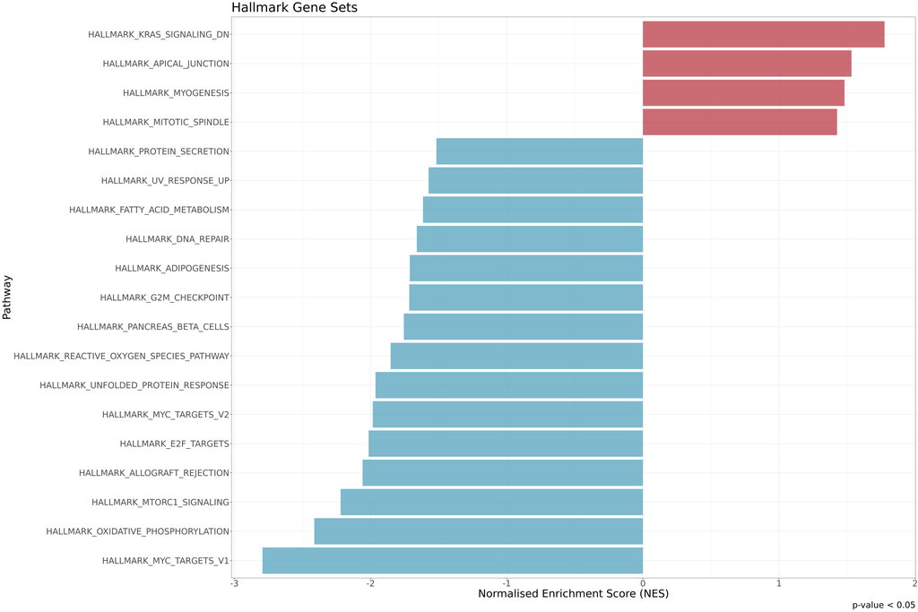

```r
hallmark.sg.t <- hallmarks.res.tidy[,c(1,6)]
hallmark.sg.t <- as.data.frame(hallmark.sg.t)

#this small part is generic
thresh <- 0.05

#this one is no longer generic
data_to_plot <- hallmarks.res.tidy %>% filter(padj < thresh)

statvec <- c()
for (i in 1:nrow(data_to_plot)){
  if (data_to_plot[i,6] > 0){
    status <- "Upregulated"
  }
 else {
   status <- "Downregulated"
 }
statvec <- c(statvec, status)
}

data_to_plot$Status <- statvec

##-----HALMARK-----
gsea_plot_hall <- ggplot(data_to_plot, aes(reorder(pathway, NES), NES)) +
  geom_col(aes(fill= Status), alpha=0.75) + scale_fill_manual(values = c("#53A2BE","#BA3B46"), name = "Regulation Status", labels = c("Downregulated", "Upregulated"), breaks = c("Downregulated", "Upregulated")) +
  coord_flip() +
  labs(x="Pathway", y="Normalised Enrichment Score (NES)",
       title= "Hallmark Gene Sets",
       caption = paste0("p-value < ", thresh)) + theme(plot.title = element_text(hjust = 1)) +
  theme_bw() + theme(text=element_text(family = "Quicksand")) + theme(legend.position = "none")

gsea_plot_hall+
  theme(text=element_text(size=25,  family="Arial MS"))
```

# G3BP1 vs G3BP1

## Volcano Plot

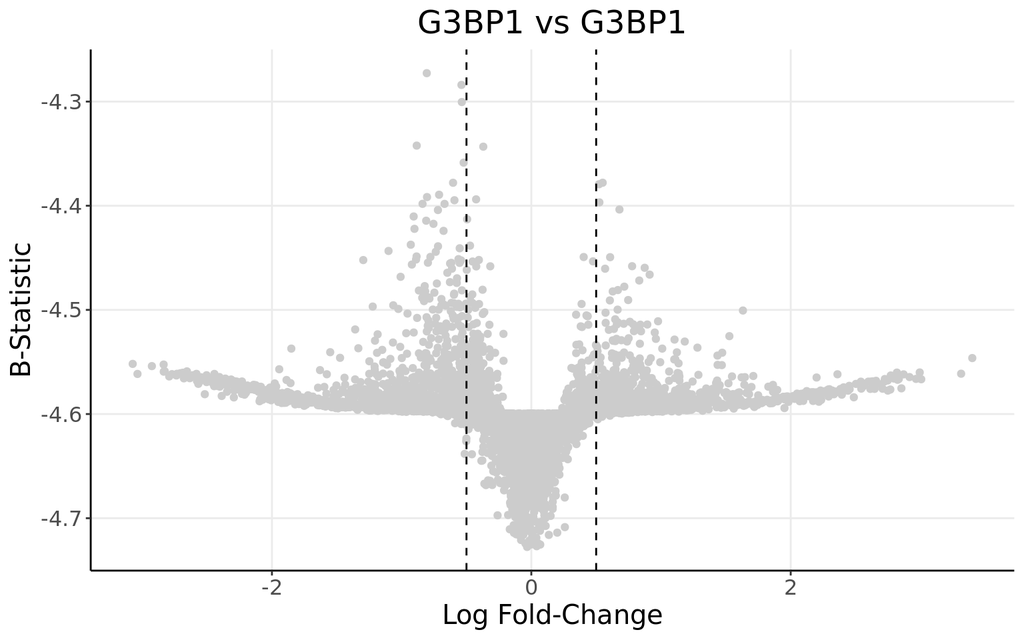

```r
ndegs <- 10
upmarkers <- as.data.frame(DEGenes_BP1.vs.BP1[DEGenes_BP1.vs.BP1$logFC>1 & DEGenes_BP1.vs.BP1$B>0,] )
downmarkers <- as.data.frame(DEGenes_BP1.vs.BP1[DEGenes_BP1.vs.BP1$logFC< -1 & DEGenes_BP1.vs.BP1$B>0,] )

ggplot(data=DEGenes_BP1.vs.BP1,
                 aes(x=logFC,
                     y=  B)) +
  geom_point(color="#CCCCCC")+ geom_vline(xintercept = -0.5, linetype="dashed")+geom_vline(xintercept = 0.5, linetype="dashed")+
  theme_bw() + ylab("B-Statistic")+xlab("Log Fold-Change")+
  theme(axis.line = element_line(colour = "black"),
        panel.grid.minor = element_blank(),
        panel.border = element_blank(),
        panel.background = element_blank()) +
  ggtitle("G3BP1 vs G3BP1")+
  theme(plot.title = element_text(hjust = 0.5), plot.subtitle = element_text(hjust = 0.5)) +
  geom_point(data=upmarkers, aes(x=logFC, y=  B), color="#A10702",size=4)+
  geom_point(data=downmarkers, aes(x=logFC, y=  B), color="#03256C",size=4)+
  geom_label_repel(upmarkers[1:ndegs,] , mapping=aes(label=row.names(upmarkers)[1:ndegs]),size=4,point.padding=-0.5, color="#A10702",max.overlaps = 20, fontface="italic")+
  geom_label_repel(downmarkers[1:ndegs,] , mapping=aes(label=row.names(downmarkers)[1:ndegs]),size=4,point.padding=-0.5, color="#03256C",max.overlaps = 20, fontface="italic")+
  theme(text=element_text(size=15,  family="Arial MS"))
```

We see no significance. As expected, since from the heatmap these sample types appeared very similar.

# G3BP2 vs G3BP2

## Volcano Plot

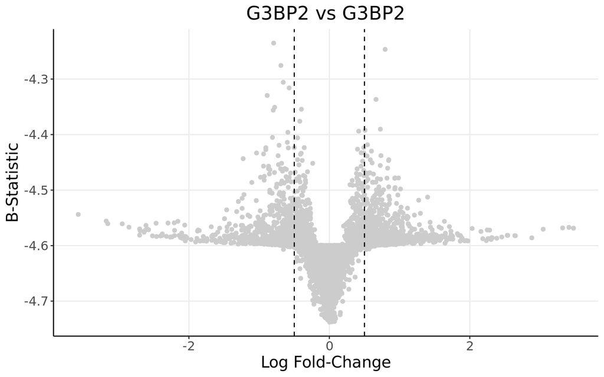

```r
ndegs <- 10
upmarkers <- as.data.frame(DEGenes_BP2.vs.BP2[DEGenes_BP2.vs.BP2$logFC>1 & DEGenes_BP2.vs.BP2$B>0,] )
downmarkers <- as.data.frame(DEGenes_BP2.vs.BP2[DEGenes_BP2.vs.BP2$logFC< -1 & DEGenes_BP2.vs.BP2$B>0,] )

ggplot(data=DEGenes_BP2.vs.BP2,
                 aes(x=logFC,
                     y=  B)) +
  geom_point(color="#CCCCCC")+ geom_vline(xintercept = -0.5, linetype="dashed")+geom_vline(xintercept = 0.5, linetype="dashed")+
  theme_bw() + ylab("B-Statistic")+xlab("Log Fold-Change")+
  theme(axis.line = element_line(colour = "black"),
        panel.grid.minor = element_blank(),
        panel.border = element_blank(),
        panel.background = element_blank()) +
  ggtitle("G3BP2 vs G3BP2")+
  theme(plot.title = element_text(hjust = 0.5), plot.subtitle = element_text(hjust = 0.5)) +
  geom_point(data=upmarkers, aes(x=logFC, y=  B), color="#A10702",size=4)+
  geom_point(data=downmarkers, aes(x=logFC, y=  B), color="#03256C",size=4)+
  geom_label_repel(upmarkers[1:ndegs,] , mapping=aes(label=row.names(upmarkers)[1:ndegs]),size=4,point.padding=-0.5, color="#A10702",max.overlaps = 20, fontface="italic")+
  geom_label_repel(downmarkers[1:ndegs,] , mapping=aes(label=row.names(downmarkers)[1:ndegs]),size=4,point.padding=-0.5, color="#03256C",max.overlaps = 20, fontface="italic")+
  theme(text=element_text(size=15,  family="Arial MS"))
```

We see no significance. As expected, since from the heatmap these sample types appeared very similar.

# Complex Linear Models

Now we must perform linear model fitting.

```
## Coefficients not estimable: fortargetNO
```

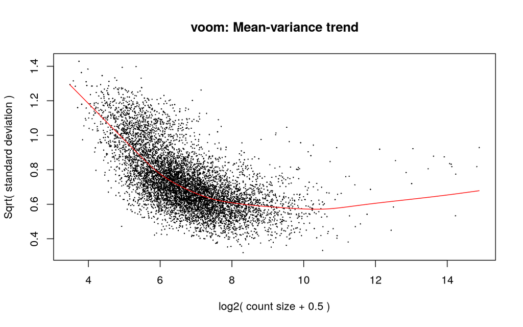

```r
#Removing the old samples
D0 <- DGEList(finaltable[,-c(1:2)])

#Then we calculate the normalization factors.
#Bear in mind this step calculates the normalization factors, but does not normalize itself.
D0 <- calcNormFactors(D0)

fordescriptive <- c("WCS_OLD", "WCU_OLD", "ECBPAR2", "ECBPAR2", "ECBPAR1", "ECBPAR1", "ECCTUN", "ECCTUN", "ECBP2UN", "ECBP2UN", "ECCTAR", "ECCTAR", "ECBP1UN", "ECBP1UN", "WCS", "WCBP2SI", "WCBP1SI", "SG", "WCU")[-c(1:2)]

fortype <- c("WC", "WC", "EC", "EC", "EC", "EC", "EC", "EC", "EC", "EC", "EC", "EC", "EC", "EC", "WC", "WC", "WC", "SG", "WC")[-c(1:2)]

forstress <- c("YES", "NO", "YES", "YES", "YES", "YES", "NO", "NO", "NO", "NO", "YES", "YES", "NO", "NO", "YES", "NO", "NO", "YES", "NO")[-c(1:2)]

fortarget <- c("NO", "NO", "G3BP2", "G3BP2", "G3BP1", "G3BP1", "CT", "CT", "G3BP2", "G3BP2", "CT", "CT", "G3BP1", "G3BP1", "NO", "NO", "NO", "NO", "NO")[-c(1:2)]

forsg <- c("NO", "NO", "YES", "YES", "YES", "YES", "NO", "NO", "NO", "NO", "NO", "NO", "NO", "NO", "NO", "NO", "NO", "YES", "NO")[-c(1:2)]

#Now we do our matrix itself
mm <- model.matrix(~0+fortype+forstress+fortarget+forsg)

#and now we normalize. This step also turns our counts into log2-counts per million.
y <- voom(D0, mm, plot = T)
```

```r
fitted_y <- lmFit(y, mm)
```

```
## Coefficients not estimable: fortargetNO
```

```r
#Just to see if everything is ok
head(coef(fitted_y))
```

```
##       fortypeEC fortypeSG fortypeWC forstressYES fortargetG3BP1 fortargetG3BP2
## A1BG   3.408361  3.153035  4.051559    0.1296038     0.83916124     0.48470576
## AAAS   5.367108  5.195144  6.334823    0.2659875    -0.59576677    -0.03668854
## AACS   3.327656  4.789327  4.490092    0.2782981     1.60716598     1.51833559
## AADAT  4.022591  4.414862  4.061492    0.1843954    -0.03286849    -0.21674455
## AAGAB  5.918197  4.631855  4.924692    0.3899676    -1.30929447    -1.26086438
## AAK1   6.476701  8.354322  4.850745   -0.6358809     1.26314646     1.04086265
##       fortargetNO      forsgYES
## A1BG           NA  0.0376206122
## AAAS           NA -0.6454349090
## AACS           NA -0.8194488494
## AADAT          NA  0.0002935196
## AAGAB          NA -0.1016321387
## AAK1           NA  0.4510323701
```

```r
tmp <- eBayes(fitted_y)
#TOP Tables
top <- topTable(tmp,8, sort.by = "logFC", n=Inf)



#DEGenes
DEGenes <- top
```

# Merged SG Signal

## Volcano Plot

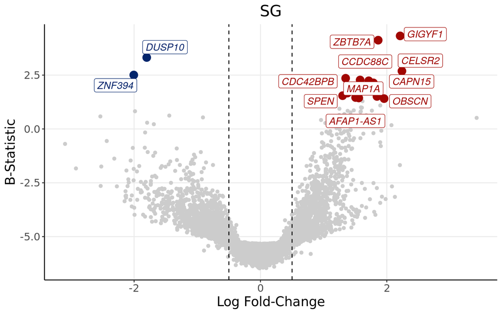

```r
ndegs <- 10
upmarkers <- as.data.frame(DEGenes[DEGenes$logFC>1 & DEGenes$adj.P.Val<0.05,] )
downmarkers <- as.data.frame(DEGenes[DEGenes$logFC< -1 & DEGenes$adj.P.Val<0.05,] )

ggplot(data=DEGenes,
                 aes(x=logFC,
                     y=  B)) +
  geom_point(color="#CCCCCC")+ geom_vline(xintercept = -0.5, linetype="dashed")+geom_vline(xintercept = 0.5, linetype="dashed")+
  theme_bw() + ylab("B-Statistic")+xlab("Log Fold-Change")+
  theme(axis.line = element_line(colour = "black"),
        panel.grid.minor = element_blank(),
        panel.border = element_blank(),
        panel.background = element_blank()) +
  ggtitle("SG")+
  theme(plot.title = element_text(hjust = 0.5), plot.subtitle = element_text(hjust = 0.5)) +
  geom_point(data=upmarkers, aes(x=logFC, y=  B), color="#A10702",size=4)+
  geom_point(data=downmarkers, aes(x=logFC, y=  B), color="#03256C",size=4)+
  geom_label_repel(upmarkers[1:ndegs,] , mapping=aes(label=row.names(upmarkers)[1:ndegs]),size=4,point.padding=-0.5, color="#A10702",max.overlaps = 20, fontface="italic")+
  geom_label_repel(downmarkers[1:ndegs,] , mapping=aes(label=row.names(downmarkers)[1:ndegs]),size=4,point.padding=-0.5, color="#03256C",max.overlaps = 20, fontface="italic")+
  theme(text=element_text(size=15,  family="Arial MS"))
```

## Volcano Plot with Gene Length

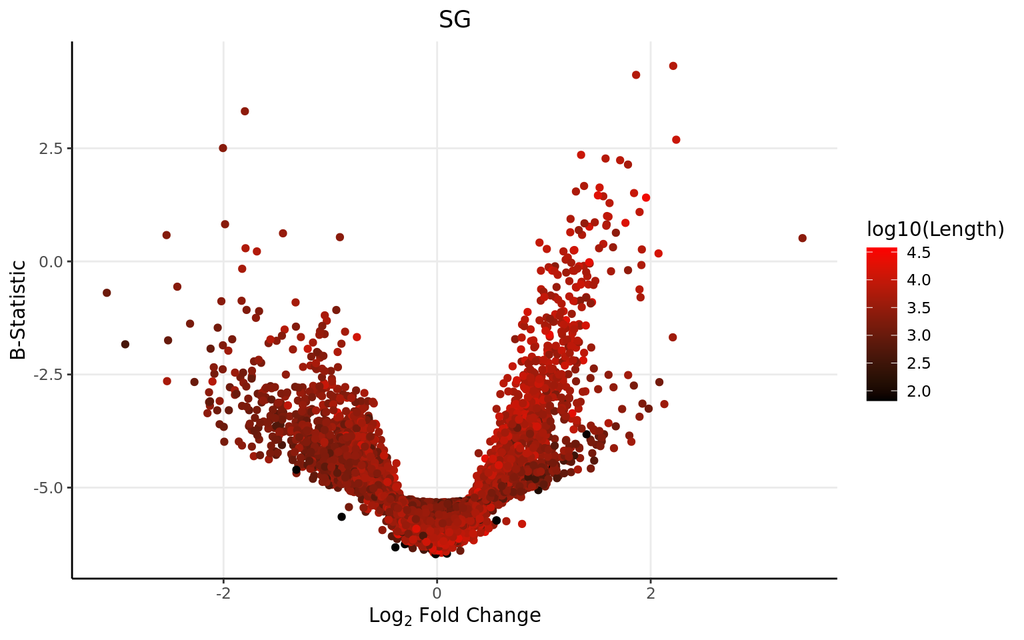

```r
DEGenes$Gene <- row.names(DEGenes)
colnames(genelength) <- c("Length","Gene")
DEGenes <- merge(DEGenes, genelength, by="Gene")

ggplot(data=DEGenes,
                 aes(x=logFC,
                     y=  B)) +
  geom_point(aes(color=log10(Length)))+
  theme_bw() +
  theme(axis.line = element_line(colour = "black"),
        panel.grid.minor = element_blank(),
        panel.border = element_blank(),
        panel.background = element_blank()) +
  ggtitle("SG")+ xlab(expression(Log[2] ~ Fold ~ Change)) + ylab("B-Statistic") +
  theme(plot.title = element_text(hjust = 0.5))  +
  scale_colour_gradient(low = "black", high = "red")+ theme(text=element_text(family = "Quicksand"))
```

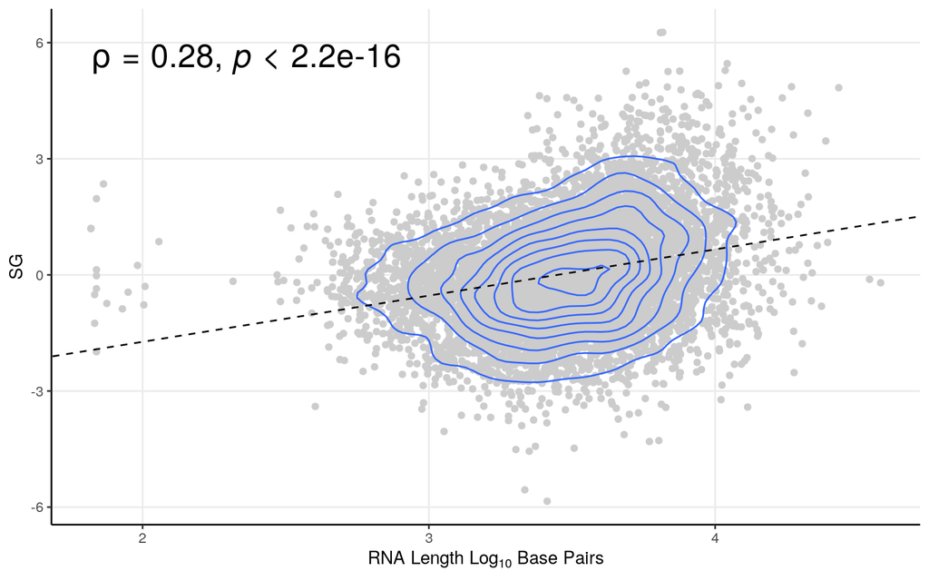

```r
smooth.SG <- lm(t~log10(Length), DEGenes)
liner.SG <- rstandard(smooth.SG)
DEGenes <-cbind(DEGenes, liner.SG)
colnames(DEGenes)[9] <- "Residuals"
row.names(DEGenes) <- DEGenes$Gene
linemarkers <- as.data.frame(DEGenes[abs(DEGenes$Residuals)>4,])

# Calculate the Spearman correlation coefficient
spearman_corr <- cor(DEGenes$t, log10(DEGenes$Length), method = "spearman")



ggplot(DEGenes, aes(y=t, x=log10(Length))) + geom_point(color="#CCCCCC", alpha=1) +   theme_bw()+ geom_density_2d()+
 ylab("SG") + xlab(expression(RNA ~ Length ~ Log[10] ~ Base ~ Pairs)) +
  theme(axis.line = element_line(colour = "black"),
        panel.grid.minor = element_blank(),
        panel.border = element_blank(),
        panel.background = element_blank()) +
  theme(plot.title = element_text(hjust = 0.5))  +
  geom_abline(slope=smooth.SG$coefficients[2], intercept = smooth.SG$coefficients[1], linetype = "dashed")+ stat_cor(method = "spearman", cor.coef.name = "rho",size=7)
```

We observe a positive lenght bias.

## Expression Graphs (Extra QC)

As an added control, lets plot these genes in regard to their expression, and contamination.

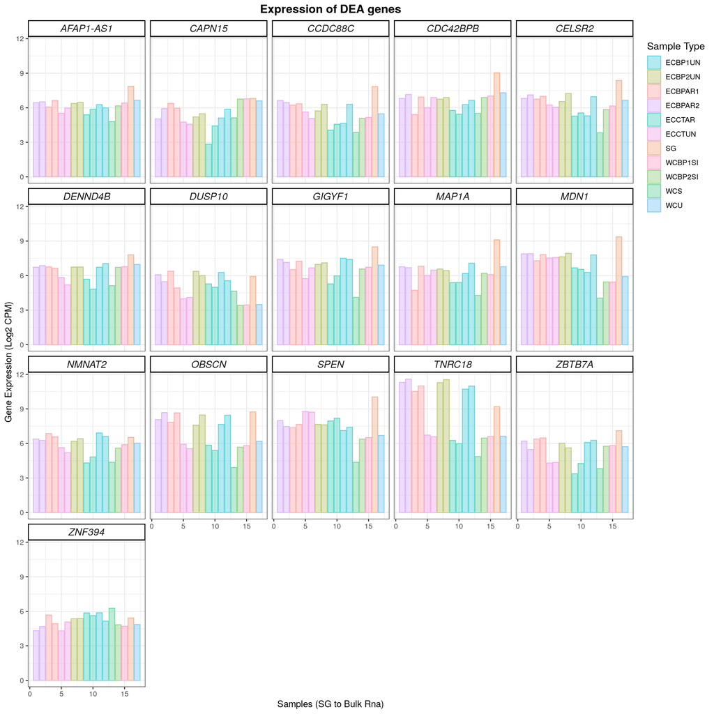

```r
upmarkers <- as.data.frame(DEGenes[DEGenes$logFC>1 & DEGenes$adj.P.Val<0.05,] )
downmarkers <- as.data.frame(DEGenes[DEGenes$logFC< -1 & DEGenes$adj.P.Val<0.05,] )

finagenes <- rbind(upmarkers, downmarkers)

dfforexpression <- dfforpca[-c(1:2),]
samplecodes <- data.frame(samples=row.names(dfforexpression), purity=c(1:17))
sampletype <- data.frame(samples=row.names(dfforexpression), sampletype=fordescriptive)
dfforexpression <- t(dfforexpression)
genesforexp <- dfforexpression[row.names(dfforexpression)%in%row.names(finagenes),]
genesforexp <- reshape2::melt(genesforexp)
colnames(genesforexp) <- c("Gene", "samples", "expression")
genesforexp <- merge(genesforexp, samplecodes, by="samples")
genesforexp <- merge(genesforexp, sampletype, by="samples")
genesforexp <- genesforexp[,-1]
genesforexp[,2] <- as.numeric(genesforexp[,2])
genesforexp[,1] <- as.character(genesforexp[,1])
genesforexp <- genesforexp[order(genesforexp$Gene),]


winnyplot <- ggplot(genesforexp, aes(x=purity, y=expression, fill=sampletype, colour=sampletype)) + geom_bar(position="dodge", stat="identity", alpha=0.5) + facet_wrap(.~ Gene, ncol=5)
winnyplot <- winnyplot + scale_fill_manual(name = "Sample Type", values = custom_palette) + scale_colour_manual(name = "Sample Type", values = custom_palette)
winnyplot <- winnyplot + theme_bw() + xlab("Samples (SG to Bulk Rna)") + ylab("Gene Expression (Log2 CPM)") + theme(
      strip.text.x = element_text(
        size = 12, face="italic"
        )) +
 theme(
   strip.background = element_rect(
     color="black", fill="#FFFFFF", size=1, linetype="solid"
     )
   ) + theme(
    #legend.position = c(.95, .40),
    legend.justification = c("right", "top"),
    legend.box.just = "right",
    ) + theme(legend.title = element_text(size = 12)) + ggtitle("Expression of DEA genes") + theme(plot.title = element_text(hjust = 0.5, size=14, face="bold"))
winnyplot
```

## GSEA

Now that we have our genes of interest, it would also be interesting to see what are the **altered gene sets** between upregulated and downregulated transcripts from the above comparison. Therefore, lets perform a *Gene Set Enrichment Analysis*

```r
#for all genes
DEGenes <- DEGenes[order(DEGenes[,4]),]
gseatool <- DEGenes[,4]
gseatool <- as.data.frame(gseatool)
colnames(gseatool)[1] <- "t"
gseatool[,2] <- DEGenes$Gene
colnames(gseatool)[2] <- "Symbol"
gseatool <- gseatool[,c(2,1)]

vectorranks <- gseatool$t
names(vectorranks) <- gseatool$Symbol


#to load our pathways
hallmarks.gs <- msigdbr(species = "Homo sapiens", collection =  "H")

hallmarks.gsets <- hallmarks.gs %>% split(x = .$gene_symbol, f = .$gs_name)

for (set in names(hallmarks.gsets)){
  hallmarks.gsets[[set]] <- toupper(hallmarks.gsets[[set]])
}

hallmarks.res <- fgsea(pathways = hallmarks.gsets,
                       stats = vectorranks)
hallmarks.res.tidy <- hallmarks.res %>%
  as_tibble() %>%
  arrange(desc(NES))

hallmarks.res.tidy %>%
  dplyr::select(-leadingEdge, -ES) %>%
  arrange(padj)
```

```
## # A tibble: 50 × 6
##    pathway                                     pval     padj log2err   NES  size
##    <chr>                                      <dbl>    <dbl>   <dbl> <dbl> <int>
##  1 HALLMARK_MYC_TARGETS_V1             0.0000000200  9.99e-7   0.734 -2.03   187
##  2 HALLMARK_MTORC1_SIGNALING           0.0000000436  1.09e-6   0.720 -2.06   158
##  3 HALLMARK_UNFOLDED_PROTEIN_RESPONSE  0.0000344     5.73e-4   0.557 -1.93    96
##  4 HALLMARK_FATTY_ACID_METABOLISM      0.000125      1.56e-3   0.519 -1.86    92
##  5 HALLMARK_OXIDATIVE_PHOSPHORYLATION  0.000181      1.81e-3   0.519 -1.63   160
##  6 HALLMARK_UV_RESPONSE_UP             0.00223       1.86e-2   0.432 -1.59    97
##  7 HALLMARK_PROTEIN_SECRETION          0.00385       2.75e-2   0.432 -1.61    66
##  8 HALLMARK_IL6_JAK_STAT3_SIGNALING    0.00868       5.42e-2   0.381  1.72    18
##  9 HALLMARK_WNT_BETA_CATENIN_SIGNALING 0.0152        6.82e-2   0.381  1.65    19
## 10 HALLMARK_HEDGEHOG_SIGNALING         0.0169        6.82e-2   0.352  1.64    20
## # ℹ 40 more rows
```

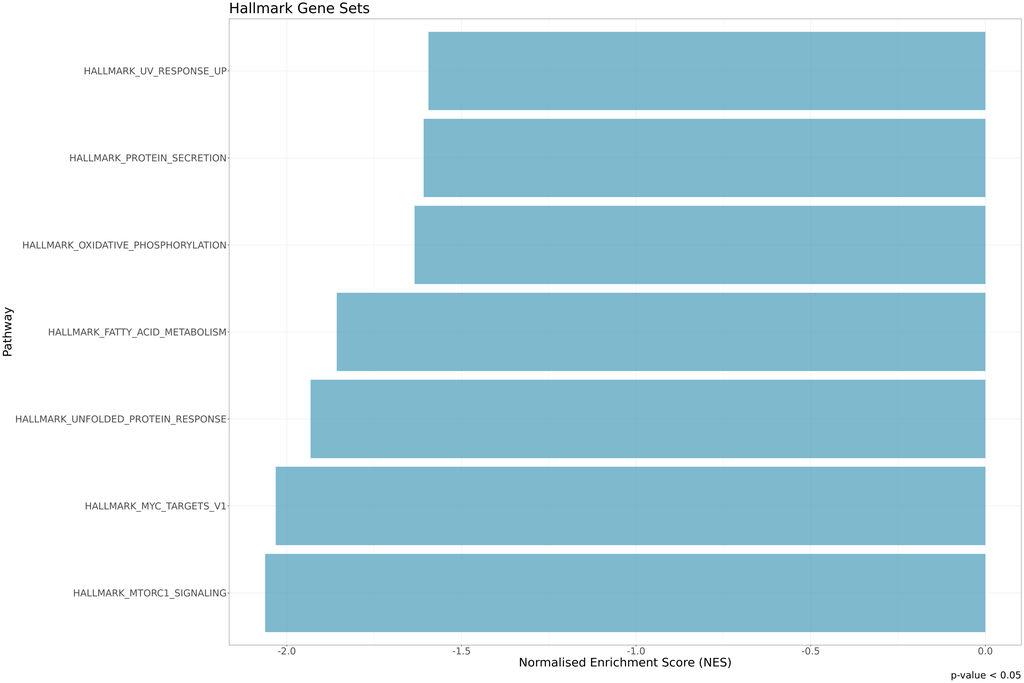

```r
hallmark.sg.t <- hallmarks.res.tidy[,c(1,6)]
hallmark.sg.t <- as.data.frame(hallmark.sg.t)

#this small part is generic
thresh <- 0.05

#this one is no longer generic
data_to_plot <- hallmarks.res.tidy %>% filter(padj < thresh)

statvec <- c()
for (i in 1:nrow(data_to_plot)){
  if (data_to_plot[i,6] > 0){
    status <- "Upregulated"
  }
 else {
   status <- "Downregulated"
 }
statvec <- c(statvec, status)
}

data_to_plot$Status <- statvec

##-----HALMARK-----
gsea_plot_hall <- ggplot(data_to_plot, aes(reorder(pathway, NES), NES)) +
  geom_col(aes(fill= Status), alpha=0.75) + scale_fill_manual(values = c("#53A2BE","#BA3B46"), name = "Regulation Status", labels = c("Downregulated", "Upregulated"), breaks = c("Downregulated", "Upregulated")) +
  coord_flip() +
  labs(x="Pathway", y="Normalised Enrichment Score (NES)",
       title= "Hallmark Gene Sets",
       caption = paste0("p-value < ", thresh)) + theme(plot.title = element_text(hjust = 1)) +
  theme_bw() + theme(text=element_text(family = "Quicksand")) + theme(legend.position = "none")

gsea_plot_hall+
  theme(text=element_text(size=25,  family="Arial MS"))
```

[^1]: Disease Transcriptomics Group, Gulbenkian Institute of Molecular Medicine